# Predicting Human Activity

Viraj Sanghvi

03/18/2015

## Selecting predictors

In order to select predictors, we load the data:

```r
library('caret');
df = read.csv("./pml-training.csv",
     header = TRUE,
     na.strings = c("NA", ""),
     stringsAsFactors = T)
```

There are over a hundred columns, so we can start by removing all columns that have NA or missing data, as well as those columns that are obviously metadata:

```r
# remove any predictors that are NA/empty
df = df[,colSums(is.na(df)) == 0]
# remove metadata fields
df = df[,-which(names(df) %in% c("X","user_name"))]
df = df[,-grep("timestamp|window", names(df))]
```

This brings us down to 52 columns. While not best practiced to explore the entire dataset, I noticed that there were a lot of predictors that were the x/y/z parameters of other predictors. Taking one, I created a feature plot on the data set:

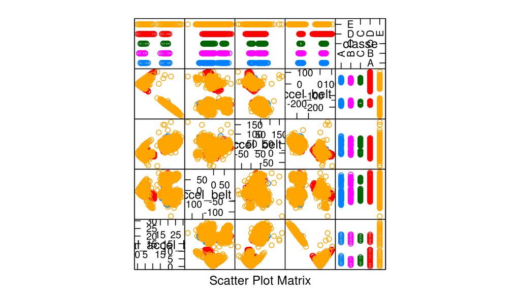

```r
featurePlot(x = df[, c("total_accel_belt","accel_belt_x","accel_belt_y", "accel_belt_z","classe")],
            y = df$classe,
            plot = "pairs")
```

Looking at this plot, it confirmed my suspicions that there is not much added value in the multiple variables - they all don’t seem particularly helpful, and there’s no added information.

To quickly confirm this, I quickly created a sample dataset to run a quick test by taking a 1000 sample of rows:

```r
sdf = df[sample(nrow(df), 1000),]
```

Then, I used trained a Random Forest model, with k-fold cross validation and 10 subsets, on my sample dataset, and on the same sample dataset without predictors that ended in “_x“,”_y“, and”_z“:

```r
library(parallel);
library(doParallel);
set.seed(1234)
trCtrl <- trainControl(method="cv", number=10)
registerDoParallel(clust <- makeForkCluster(detectCores()-1))
model_RF_10_sample <- train(classe ~., data=sdf, method="rf", trControl = trCtrl)
stopCluster(clust)
set.seed(1234)
registerDoParallel(clust <- makeForkCluster(detectCores()-1))
model_RF_10_sample_less <- train(classe ~., data=sdf[,-grep("_[xyz]$", names(sdf))], method="rf", trControl = trCtrl)
stopCluster(clust)
data.frame("sample" = model_RF_10_sample$results$Accuracy[as.numeric(row.names(model_RF_10_sample$bestTune))], "sample without x/y/z" = model_RF_10_sample_less$results$Accuracy[as.numeric(row.names(model_RF_10_sample_less$bestTune))])
```

```
##      sample sample.without.x.y.z
## 1 0.9069568            0.8920562
```

As we can see, we are still close in accuracy, even without those parameters. Even though this isn’t super scientific, this and the feature plot make we willing to drop these parameters as your total number of predictors will come down to 16:

```r
df = df[,-grep("_[xyz]$", names(df))]
```

## Model Selection

```r
# Random Forest
set.seed(1234)
trCtrl <- trainControl(method="cv", number=10)
registerDoParallel(clust <- makeForkCluster(detectCores()-1))
model_RF_cv_10 <- train(classe ~.,data=df, method="rf", trControl = trCtrl)
stopCluster(clust)

# Neural Network
set.seed(1234)
trCtrl <- trainControl(method="cv", number=10)
registerDoParallel(clust <- makeForkCluster(detectCores()-1))
model_NNET_cv_10 <- train(classe ~.,data=df, method="nnet", trControl = trCtrl)
stopCluster(clust)

# Partial Least Square
set.seed(1234)
trCtrl <- trainControl(method="cv", number=10)
registerDoParallel(clust <- makeForkCluster(detectCores()-1))
model_PLS_cv_10 <- train(classe ~.,data=df, method="pls", trControl = trCtrl)
stopCluster(clust)

# Stochastic Gradient Boosting
set.seed(1234)
trCtrl <- trainControl(method="cv", number=10)
registerDoParallel(clust <- makeForkCluster(detectCores()-1))
model_GBM_cv_10 <- train(classe ~.,data=df, method="gbm", trControl = trCtrl)
stopCluster(clust)
```

The accuracy results from those runs are:

```r
data.frame(
  "Random Forest" = model_RF_cv_10$results$Accuracy[as.numeric(row.names(model_RF_cv_10$bestTune))],
  "Neural Networks" = model_NNET_cv_10$results$Accuracy[as.numeric(row.names(model_NNET_cv_10$bestTune))],
  "Partial Least Squares" = model_PLS_cv_10$results$Accuracy[as.numeric(row.names(model_PLS_cv_10$bestTune))],
  "Stochastic Gradient Boosting" = model_GBM_cv_10$results$Accuracy[as.numeric(row.names(model_GBM_cv_10$bestTune))])
```

```
##   Random.Forest Neural.Networks Partial.Least.Squares
## 1     0.9926608       0.4470519             0.3455323
##   Stochastic.Gradient.Boosting
## 1                    0.9391994
```

As Random Forest we can move forward with it and try it out with a repeated k-fold cross validation with k = 20 and repeats = 5:

```r
# Random Forest
set.seed(1234)
trCtrl <- trainControl(method="repeatedcv", number=20, repeats = 5)
registerDoParallel(clust <- makeForkCluster(detectCores()-1))
model_RF_repeatedcv_20_5 <- train(classe ~.,data=df, method="rf", trControl = trCtrl)
stopCluster(clust)
```

```r
model_RF_repeatedcv_20_5
```

```
## Random Forest
##
## 19622 samples
##    16 predictors
##     5 classes: 'A', 'B', 'C', 'D', 'E'
##
## No pre-processing
## Resampling: Cross-Validated (20 fold, repeated 5 times)
##
## Summary of sample sizes: 18641, 18641, 18641, 18641, 18641, 18641, ...
##
## Resampling results across tuning parameters:
##
##   mtry  Accuracy   Kappa      Accuracy SD  Kappa SD
##    2    0.9916522  0.9894407  0.003078893  0.003894665
##    9    0.9926511  0.9907044  0.002314384  0.002927679
##   16    0.9899603  0.9873015  0.002847009  0.003600924
##
## Accuracy was used to select the optimal model using  the largest value.
## The final value used for the model was mtry = 9.
```

## Final model

Given this data, we can use this Random Forest model as our final model. We can estimate the out of sample error to be the following percent:

```r
(1 - model_RF_repeatedcv_20_5$results$Accuracy[as.numeric(row.names(model_RF_repeatedcv_20_5$bestTune))])*100
```

```
## [1] 0.734892
```